# BioQuery API

cywhale cyrain＠gmail.com

2019-07-04

Open API to get statitical results from bio-database, ODB, Institute of  
Oceanography, NTU. The API is in development stage and documentation is  
under construction. Updates will be continued. Now the bioquery API have  
following functions

- bioquery
- geo2map
- geo2wwwmap
- txt2geojson
- site_intersect

# Open API.01

## POST

keyword: *bioquery site2map*

**API cURL url:** https://bio.odb.ntu.edu.tw/api/bioquery/png {jpeg, pdf, svg}

site2map can plot sites, polygons, and overaly of environmental layer.  
Basically it calls geo2map API, and can be incorporated with query  
criteria from BioQuery web applications in bio.odb.ntu.edu.tw/query

## Body

formdata

| config | Query crieteria downloaded from BioQuery: bio.odb.ntu.edu.tw/query, or a config text, json, or yaml file. |
| --- | --- |
| return_type | “site2map” return data type, here, “site2map” can return png, jpeg, svg, or pdf |
| legend_pos | “bottom” Optional. Legend positon: “none” (no legend) “bottomright”, “topleft”, “right”, “bottom”, and so on |

## cURL

Example Request: bioquery  
site2map

```
curl --location --request POST "https://bio.odb.ntu.edu.tw/api/bioquery/png" \
  --form "config=@Your_File_Path" \
  --form "return_type=\"site2map\"" \
  --form "legend_pos=\"bottom\""
```

## Response

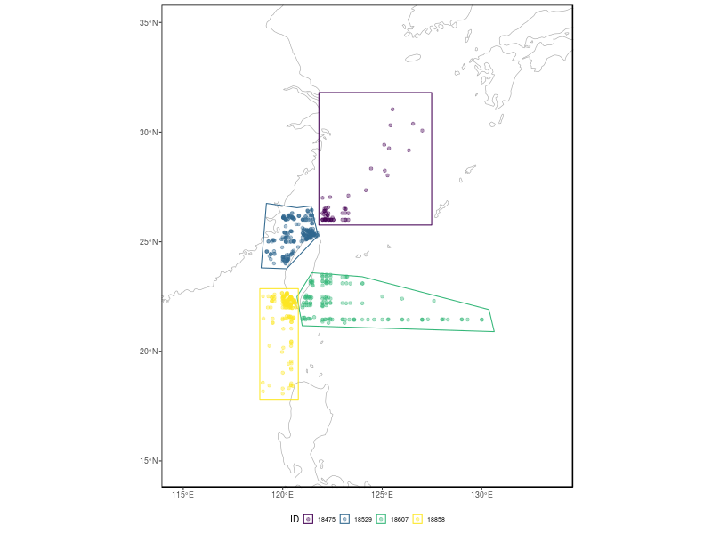

# Open API.02

## POST

keyword: *bioquery upload user data*

**API cURL url:** https://bio.odb.ntu.edu.tw/api/bioquery/png {jpeg, pdf, svg}

Users can upload community abundance data of species assemblages, which  
can be combined with ODB data (by ‘config’ parameter). This combined  
data then can be used in various statistics or plotting according to  
‘return_type’ parameter. Data format and rules of combination see:  
https://bio.odb.ntu.edu.tw/query/?help=user_data

## Body

formdata

[output not shown]

## cURL

Example Request: bioquery upload user data

```
curl --location --request POST "https://bio.odb.ntu.edu.tw/api/bioquery/png" \
  --form "config=@Your_File_Path" \
  --form "return_type=\"site2map\"" \
  --form "datasrc=@Your_File_Path" \
  --form "data_mode=\"combine\"" \
  --form "data_id=\"taxon\"" \
  --form "data_val=\"taxon_count\"" \
  --form "data_group=\"polyID\"" \
  --form "geopoly=@Your_File_Path" \
  --form "format=\"csv_poly\"" \
```

## Response

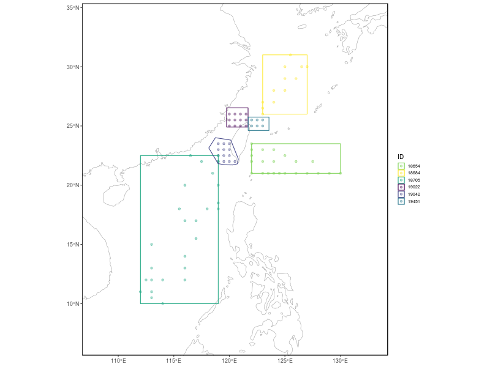

# Open API.03

## POST

keyword: *bioquery overlay environmental layer*

**API cURL url:** https://bio.odb.ntu.edu.tw/api/bioquery/png {jpeg, pdf, svg}

Environmental (Env) factors can be specified or uploaded and used in  
succeeding analysis. Specify ‘envsrc’ which means various sources of env  
databases compiled by ODB, and ‘env_layer’, i.e., the env factors  
contained in this source. Each env-layer can be applied with spatially  
kriging, transformed, and scaled. Details see:  
https://bio.odb.ntu.edu.tw/query/?help=bioenv

## Body

formdata

[output not shown]

## cURL

Example Request: bioquery overlay  
environmental layer

```
curl --location --request POST "https://bio.odb.ntu.edu.tw/api/bioquery/png" \
  --form "return_type=\"site2map\"" \
  --form "env_layer=\"chl\"" \
  --form "envsrc=\"nasa_neo\"" \
  --form "by_season=true" \
  --form "scale_res=\"large\"" \
  --form "getenv_options='{\\\"en_trans\\\":[\\\"1\\\"], \\\"scale_fun\\\":[\\\"log\\\"], \\\"scale_mul\\\":[\\\"1000\\\"], \\\"en_kriging\\\":[\\\"0\\\"]}'" \
  --form "geopoly=\"BBOX (110,15,130,35)\"" \
  --form "format=\"bbox\"" \
  --form "en_poly_border=false" \
```

## Response

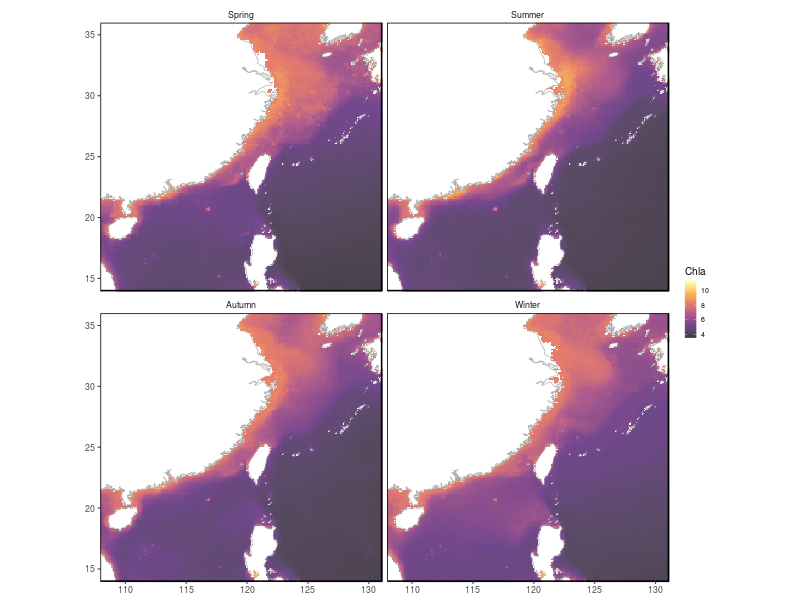